# 2019 NFL QB Data

# Normality

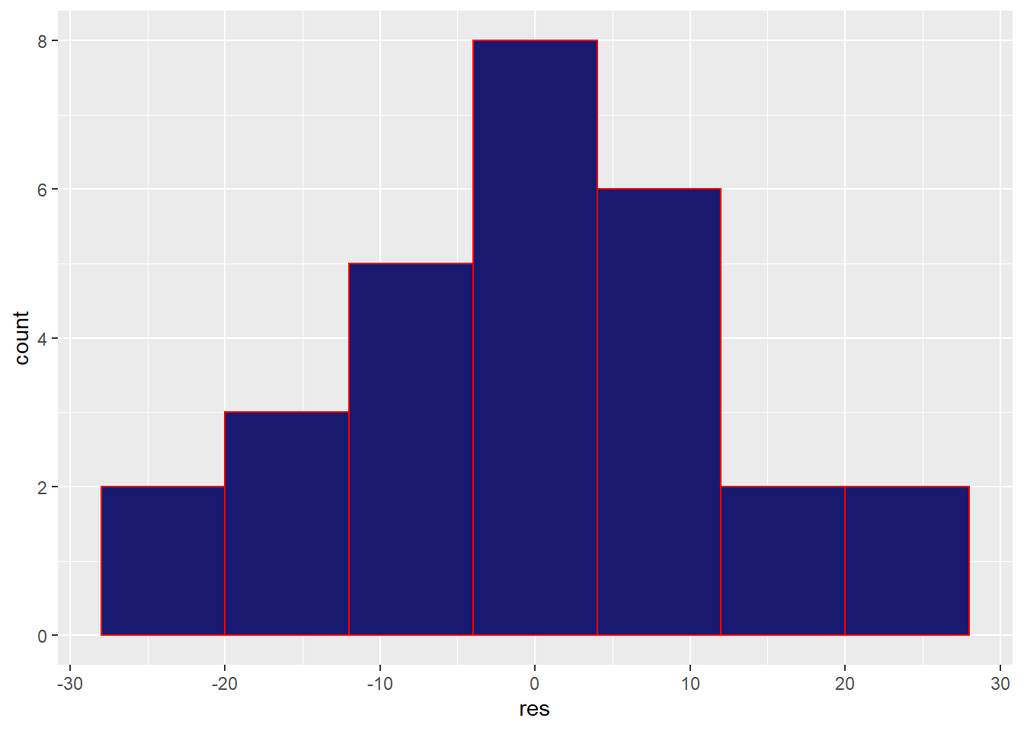

Based on the plots shown above and below, the data displays normal distributed attributes.

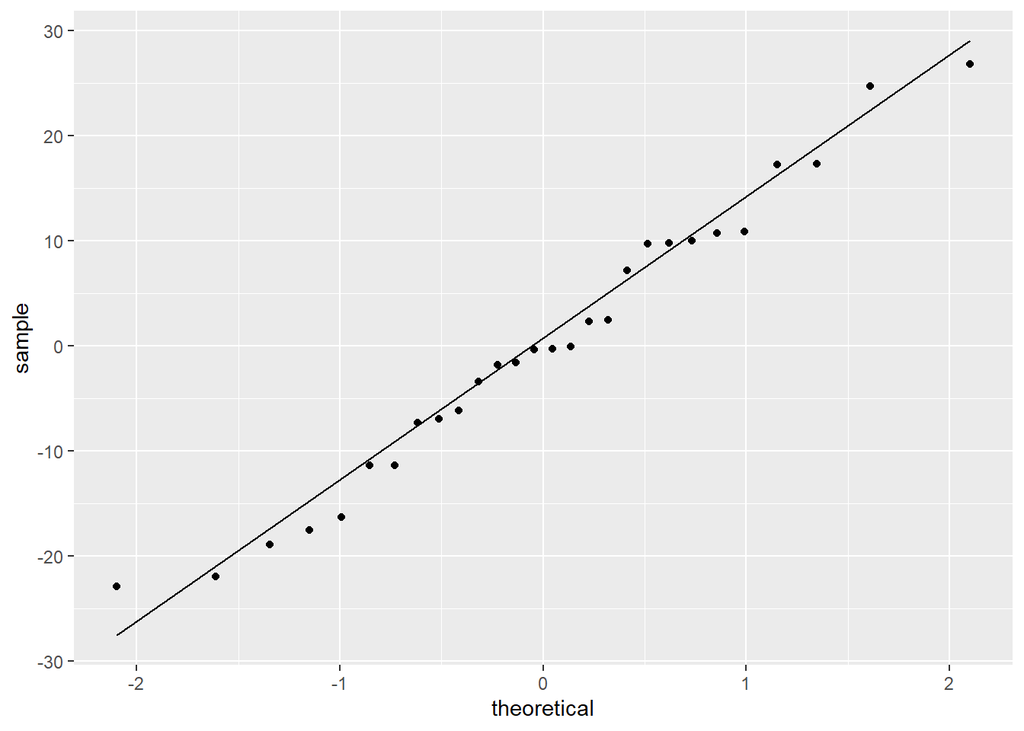

# Interpretation

Considering the original questions, which were:

- Do quarterbacks with a higher passer rating have more wins?
- Do quarterbacks with a lower passer rating have fewer wins?
- How many wins can we expect to get when we have a starting quarterback with a particular passer rating?

The answer to these questions is generally, yes, the higher the passing rating, the higher the potential for winning, therefore the expected wins are higher.

But the fact that there isn’t a massively strong relationship between the two can indicate that there are several underlying factors that contribute to a team’s success. There are a couple of things passer rating doesn’t factor in. One of these is rushing yards, which could be implemented often, especially in situations close to the endzone. Another is team defense. A team could have the best QB in the world, but if his defensive lineup consistently lets in touchdowns, they are likely to lose just as much as they win, and the passer rating would not suffer as a result/ Something else to be considered is the strength of the QB’s receivers. The QB could be making the ‘correct’ decision pass-wise, but his receivers may let him down by not being in the right spot, fumbling the ball, and having the play result in an incomplete pass. In this case the onus is not on the QB, but the receivers. If that truly is the case, then more scouting would have to be done to find receivers that can be in the right place at the right time, increasing the passer rating of his QB and therefore increasing the potential chance of victory.

That being said, the QB is probably the most important player on the team, as the play centres around them being able to make the right play at the right time in order to give his team the best chance of scoring points. It would be interesting to see how much being solid defensively contributes to winning percentage, but that’s for another time.